# E07 - RNA-seq / 05 - gene set analysis (Analysis of Gene Expression @ UCT Prague)

Copy, please, these files and directories to your personal directory:

```bash
cp -r ~/shared/AGE_current/Exercises/E07-RNA_seq/05_gene_set_analysis ~/AGE/Exercises/E07-RNA_seq
```

# Introduction

From our data we get a list of differentially expressed genes (DEGs), but what if:

- **There is too few DEGs?**
- **There are too many DEGs?**
- **We are not sure what is a biological meaning of the found DEGs?**

The solution is gene set analysis (also called functional profiling or gene set enrichment analysis). It allows to get biological insight at the level of biological processes, metabolic pathways, regulation by transcription factors or miRNAs, etc.

The fundamental concept of gene set analysis is testing gene sets rather than single genes. Gene set is a group of genes involved in a specific biological process or pathway. We can test if genes from our experiment are over-represented in such gene set and conclude if, e.g. pathway, is regulated.

# Data preparation

We will use our saved results from the differential expression exercise

```r
library(conflicted)
library(here)
library(DESeq2)
conflict_prefer("rowRanges", "MatrixGenerics")
library(magrittr)
library(stringr)
library(glue)
library(ggplot2)

load(here("E07-RNA_seq/04_differential_expression/04_differential_expression.RData"))
```

# Databases

There are many databases which provide gene sets. Some of them are very coarse (GO terms), whereas some provide finer gene sets at the level of individual pathways (KEGG, Reactome).

## Gene ontology

[Gene ontology](http://geneontology.org/) has three main groups (trees) of terms:

- Biological Process (BP)
- Molecular Function (MF)
- Cellular Component (CC)

Very nice browser of GO terms is [AmiGO 2](http://amigo.geneontology.org/amigo).

## KEGG: Kyoto Encyclopedia of Genes and Genomes

[KEGG](https://www.kegg.jp/) is a database resource for understanding high-level functions and utilities of the biological system, such as the cell, the organism and the ecosystem, from molecular-level information, especially large-scale molecular datasets generated by genome sequencing and other high-throughput experimental technologies.

## Reactome

[Reactome](https://reactome.org/) is an open-source, open access, manually curated and peer-reviewed pathway database.

## WikiPathways

[WikiPathways](https://www.wikipathways.org/) is a database of biological pathways maintained by and for the scientific community.

## MSigDB

The Molecular Signatures Database ([MSigDB](https://www.gsea-msigdb.org/gsea/msigdb/index.jsp)) is a collection of annotated gene sets. There are gene sets such as hallmark, curated disease gene sets, KEGG, GO, Reactome and many more.

# Over-representation analysis (ORA)

This is the most basic test of gene set enrichment. We are testing whether [odds ratio](https://en.wikipedia.org/wiki/Odds_ratio) in 2x2 contingency table is different from 1, using the [Fisher’s exact test](https://en.wikipedia.org/wiki/Fisher%27s_exact_test). So the null hypothesis is

$$H_0:
\frac{(up/notup)_{universe}}{(up/notup)_{geneset}} = 1$$

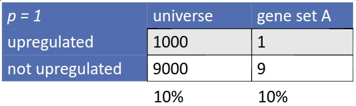

An example of not significant over-representation.

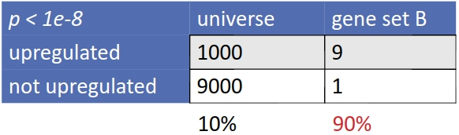

An example of significant over-representation.

## `goseq`

From [Matthew D Young et al., 2010](https://genomebiology.biomedcentral.com/articles/10.1186/gb-2010-11-2-r14) ([goseq](https://bioconductor.org/packages/release/bioc/html/goseq.html)) paper:

In RNA-seq experiments the expression level of a transcript is estimated from the number of reads that map to that transcript. But longer transcripts are yielding more reads, and thus longer transcripts give more statistical power for detecting differential expression between samples. Similarly, more highly expressed transcripts have a greater number of reads and greater power to detect differential expression.

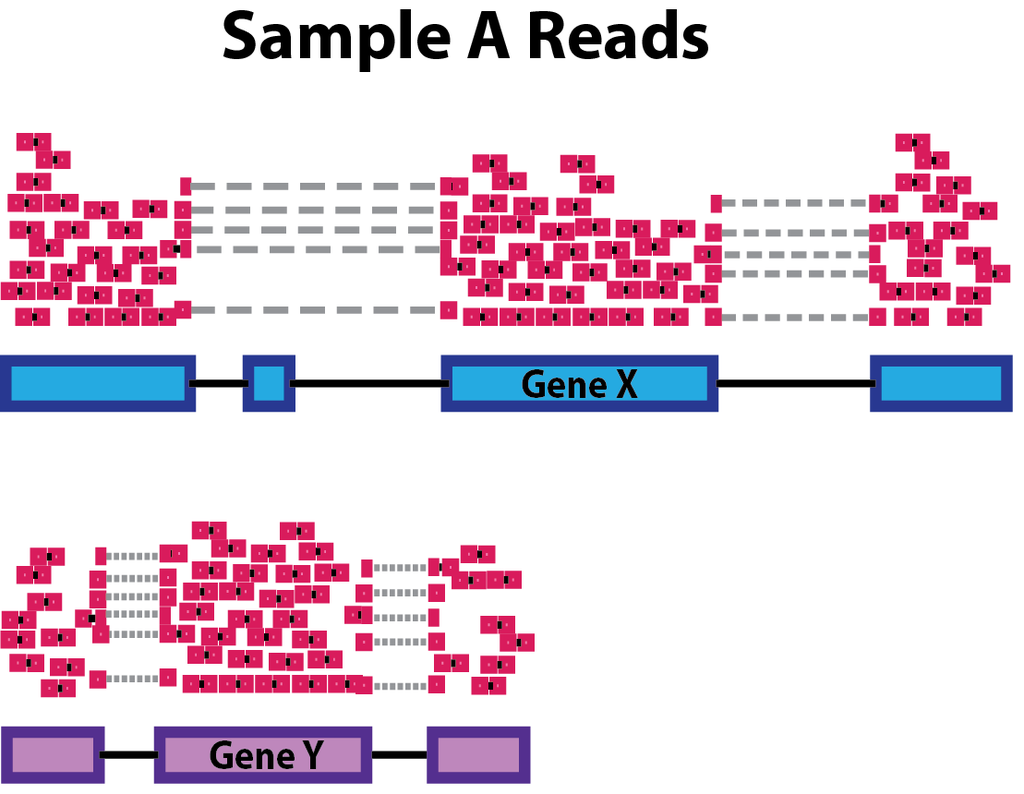

An example of gene length bias. [Source](https://github.com/hbctraining/DGE_workshop/blob/master/lessons/02_DGE_count_normalization.md)

In ORA, it is assumed that all genes are independent and equally likely to be selected as DE, under the null hypothesis. It is this assumption that makes the standard GO analysis methods unsuitable for RNA-seq data due to the bias in detecting differential expression for genes with a high number of reads. It follows then that when using a standard analysis, any category containing a preponderance of long genes will be more likely to show up as over-represented than a category with genes of average length. Similarly, categories with highly expressed genes are also more likely to be found as over-represented than categories of lowly expressed genes. Having identified this issue, it is possible to compensate for the effect of selection bias in the statistical test of a category’s enrichment among differentially expressed genes.

> TLDR: In ORA and in case of RNA-seq data, `goseq` accounts for the bias in length of genes/transcripts, which causes that longer genes/transcripts are producing more reads, and thus, are more likely to be called as differentially expressed. **You don’t need `goseq` for microarrays.**

As an input, `goseq` needs a named vector:

- **Names = IDs of measured genes**. All genes for which RNA-seq data was gathered for your experiment. Each element of your vector should be named by a unique gene identifier.
- **Values = 0/1 indicating DE status**. Each element of your vector should be either 1 or 0, where 1 indicates that the gene is differentially expressed and 0 that it is not.

We will get this named vector from `DESeq2` results. We reuse the boolean vector we used before for filtering DEGs from the results table (`res_dex_shrink` - differences between dex-treated and untreated cells):

```r
genes <- as.integer(deg_filter)
names(genes) <- rownames(res_dex_shrink)
head(genes)
```

[output not shown]

If organism in your experiment isn’t something unusual, `goseq` will provide all the necessary information (genes in GO terms, gene lengths, etc.). To show available databases:

```r
library(goseq)
supportedOrganisms()
```

|  | Genome | Id | Id Description | Lengths in geneLeneDataBase | GO Annotation Available |
| --- | --- | --- | --- | --- | --- |
| 10 | anoCar1 | ensGene | Ensembl gene ID | TRUE | FALSE |
| 11 | anoGam1 | ensGene | Ensembl gene ID | TRUE | TRUE |
| 98 | anoGam3 |  |  | FALSE | TRUE |
| 12 | apiMel2 | ensGene | Ensembl gene ID | TRUE | FALSE |
| 138 | Arabidopsis |  |  | FALSE | TRUE |
| 56 | bosTau2 | geneSymbol | Gene Symbol | TRUE | TRUE |
| 13 | bosTau3 | ensGene | Ensembl gene ID | TRUE | TRUE |
| 57 | bosTau3 | geneSymbol | Gene Symbol | TRUE | TRUE |
| 14 | bosTau4 | ensGene | Ensembl gene ID | TRUE | TRUE |
| 58 | bosTau4 | geneSymbol | Gene Symbol | TRUE | TRUE |

[output cut: 131 more lines]

We can see that data for our human reference genome (hg19, ensGene) are available.

First we calculate a probability weighting function (PWF). The PWF quantifies how the probability of a gene selected as DE changes as a function of its transcript length.

```r
pwf <- nullp(genes, genome = "hg19", id = "ensGene")
```

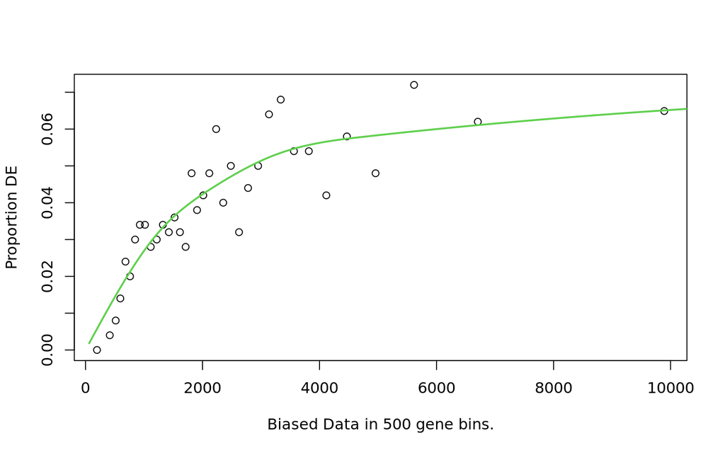

The proportion of DE genes is plotted as a function of the transcript length. The green line is the probability weighting function. A clear trend towards more detected differential expression at longer gene lengths can be seen.

Having the PWF, we can now test GO terms enrichment:

```r
goseq_go_results <- goseq(pwf, genome = "hg19", id = "ensGene")
head(goseq_go_results)
```

|  | category | over_represented_pvalue | under_represented_pvalue | numDEInCat | numInCat | term | ontology |
| --- | --- | --- | --- | --- | --- | --- | --- |
| 21646 | GO:2001233 | 1.215667e-05 | 0.9999954 | 32 | 305 | regulation of apoptotic signaling pathway | BP |
| 10015 | GO:0038034 | 2.263852e-05 | 0.9999963 | 11 | 52 | signal transduction in absence of ligand | BP |
| 16963 | GO:0097192 | 2.263852e-05 | 0.9999963 | 11 | 52 | extrinsic apoptotic signaling pathway in absence of ligand | BP |
| 13232 | GO:0051247 | 3.008434e-05 | 0.9999825 | 91 | 1214 | positive regulation of protein metabolic process | BP |
| 2549 | GO:0005737 | 4.989586e-05 | 0.9999659 | 522 | 9813 | cytoplasm | CC |
| 924 | GO:0002339 | 5.883971e-05 | 1.0000000 | 3 | 3 | B cell selection | BP |

GO terms are sorted by over-representation p-values. You can see the size of GO term (`numInCat`) and number of DEGs in that term (`numDEInCat`).

You can also test KEGG pathways enrichment:

```r
goseq_kegg_results <- goseq(pwf, genome = "hg19", id = "ensGene", test.cats = "KEGG")
head(goseq_kegg_results)
```

|  | category | over_represented_pvalue | under_represented_pvalue | numDEInCat | numInCat |
| --- | --- | --- | --- | --- | --- |
| 216 | 05222 | 0.005615485 | 0.9979829 | 13 | 79 |
| 76 | 00860 | 0.010730551 | 0.9980477 | 5 | 22 |
| 199 | 05145 | 0.011411405 | 0.9952842 | 14 | 104 |
| 38 | 00480 | 0.022051212 | 0.9940554 | 6 | 42 |
| 82 | 00982 | 0.027342072 | 0.9922693 | 6 | 41 |
| 203 | 05200 | 0.027439379 | 0.9836523 | 29 | 280 |

But you can see that the annotation for KEGG is not very good as there are only KEGG IDs in the `category` column. For example, `00750` is pathway hsa00750.

It is possible to retrieve information from KEGG using its [REST API](https://www.kegg.jp/kegg/rest/keggapi.html) to which [KEGGREST](http://bioconductor.org/packages/release/bioc/html/KEGGREST.html) package provides programmatic access. We will use `keggList()` function to retrieve mapping of pathway IDs to their human-readable names:

```r
kegg_pathways <- KEGGREST::keggList("pathway", organism = "hsa")
head(kegg_pathways)
```

```
##                                                     path:hsa00010                                                     path:hsa00020
##             "Glycolysis / Gluconeogenesis - Homo sapiens (human)"                "Citrate cycle (TCA cycle) - Homo sapiens (human)"
##                                                     path:hsa00030                                                     path:hsa00040
##                "Pentose phosphate pathway - Homo sapiens (human)" "Pentose and glucuronate interconversions - Homo sapiens (human)"
##                                                     path:hsa00051                                                     path:hsa00052
##          "Fructose and mannose metabolism - Homo sapiens (human)"                     "Galactose metabolism - Homo sapiens (human)"
```

The results is a named vector, with names and values being pathway IDs and their descriptions, respectively. We remove the `path:` prefixes from the names and convert it to dataframe. In `goseq_kegg_results$category` we add `hsa` prefix. Finally, we join both dataframes.

```r
kegg_pathways <- data.frame(category = str_remove(names(kegg_pathways), fixed("path:")), description = kegg_pathways)
head(kegg_pathways)
```

|  | category | description |
| --- | --- | --- |
| path:hsa00010 | hsa00010 | Glycolysis / Gluconeogenesis - Homo sapiens (human) |
| path:hsa00020 | hsa00020 | Citrate cycle (TCA cycle) - Homo sapiens (human) |
| path:hsa00030 | hsa00030 | Pentose phosphate pathway - Homo sapiens (human) |
| path:hsa00040 | hsa00040 | Pentose and glucuronate interconversions - Homo sapiens (human) |
| path:hsa00051 | hsa00051 | Fructose and mannose metabolism - Homo sapiens (human) |
| path:hsa00052 | hsa00052 | Galactose metabolism - Homo sapiens (human) |

```r
goseq_kegg_results <- goseq_kegg_results %>%
  dplyr::mutate(category = paste0("hsa", category)) %>%
  dplyr::left_join(kegg_pathways, by = "category") %>%
  dplyr::select(category, description, dplyr::everything())
head(goseq_kegg_results)
```

|  | category | description | over_represented_pvalue | under_represented_pvalue | numDEInCat | numInCat |
| --- | --- | --- | --- | --- | --- | --- |
| 1 | hsa05222 | Small cell lung cancer - Homo sapiens (human) | 0.005615485 | 0.9979829 | 13 | 79 |
| 2 | hsa00860 | Porphyrin metabolism - Homo sapiens (human) | 0.010730551 | 0.9980477 | 5 | 22 |
| 3 | hsa05145 | Toxoplasmosis - Homo sapiens (human) | 0.011411405 | 0.9952842 | 14 | 104 |
| 4 | hsa00480 | Glutathione metabolism - Homo sapiens (human) | 0.022051212 | 0.9940554 | 6 | 42 |
| 5 | hsa00982 | Drug metabolism - cytochrome P450 - Homo sapiens (human) | 0.027342072 | 0.9922693 | 6 | 41 |
| 6 | hsa05200 | Pathways in cancer - Homo sapiens (human) | 0.027439379 | 0.9836523 | 29 | 280 |

### Using custom length and GO data

If you don’t find your genome in `supportedOrganisms()`, you can quite easily make your own data.

For length data, you need to prepare a numeric vector of the same length as the input vector with gene names and DE status. You can use a corresponding `TxDb` of your genome, as we did for calculating TPM in the exercise `03_exploratory_analysis`, and get a vector of median transcript lengths of each gene (the `gene_lengths` variable).

For GO data you need to provide a dataframe with two columns: gene ID (ENSEMBL) and GO category. You can use annotation packages such as `org.Hs.eg.db` for human:

```r
library(org.Hs.eg.db)
go_ann <- AnnotationDbi::select(org.Hs.eg.db, keys = keys(org.Hs.eg.db), columns = c("ENSEMBL", "GOALL")) %>%
  dplyr::select(ENSEMBL, GOALL)
```

We obtained only GO term IDs, which are not very meaningful. However, we can use `clusterProfiler::go2term(go_ann$GOALL)` to retrieve GO term descriptions.

## `clusterProfiler`

In case of microarray data or if you for some reason don’t want to use `goseq`, ORA can be easily performed in [clusterProfiler](https://bioconductor.org/packages/release/bioc/html/clusterProfiler.html) package, which is also used for GSEA in the next section.

# Gene Set Enrichment Analysis (Subramanian) on KEGG

This method is the original gene set enrichment analysis (GSEA) method. ([Subramanian’s paper](https://www.pnas.org/content/102/43/15545#sec-1)). In contrast with ORA, GSEA takes into account all relevant genes and their order. The principle is simple:

- We have a list L with all genes, sorted by some statistic (LFC, p-value, t-statistic, Wald statistic, etc.).
- We have a list S with genes of our interest (gene set).
- Iterate through the list L and:
  - If gene is in the list S, increase a running-sum statistic. The magnitude of the increment depends on the statistic.
  - If gene is not in the list S, decrease a running-sum statistic.
- An Enrichment Score (ES) is the maximum deviation from zero encountered in the random walk.
- A Normalized Enrichment Score (NES) accounts for gene set size and can be used to compare analysis results across different gene sets.
- A Leading-Edge Subset is the core of a gene set that accounts for the enrichment signal. High scoring gene sets can be grouped on the basis of leading-edge subsets of genes that they share. Such groupings can reveal which of those gene sets correspond to the same biological processes and which represent distinct processes.

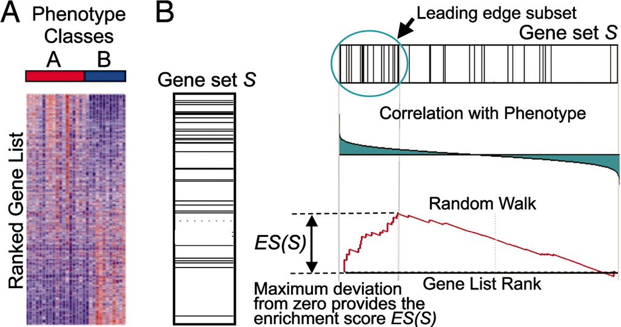

[Source](https://www.pnas.org/content/102/43/15545#sec-1)

We will use [clusterProfiler](https://bioconductor.org/packages/release/bioc/html/clusterProfiler.html) which offers updated gene sets for most of the popular databases (GO, KEGG, Reactome, etc.). `clusterProfiler` can do both ORA and GSEA, but for ORA is better `goseq` due to the correction of gene length bias. Also, `clusterProfiler` provides a rich set of visualization functions, some of them through the [enrichplot](https://bioconductor.org/packages/release/bioc/html/enrichplot.html) package.

There is a nice [overview](https://bioconductor.org/packages/release/bioc/vignettes/clusterProfiler/inst/doc/clusterProfiler.html) of `clusterProfiler` abilities, and also a more detailed [book](https://yulab-smu.github.io/clusterProfiler-book/index.html), where you can also find guides how to use more “exotic” gene set sources. There is also an alternative book from the same author [Biomedical Knowledge Mining using GOSemSim and clusterProfiler](https://yulab-smu.top/biomedical-knowledge-mining-book/index.html) covering also the [GOSemSim](https://www.bioconductor.org/packages/release/bioc/html/GOSemSim.html) package.

There are already implemented functions for GO, KEGG and some disease-related gene set sources. For custom gene sets, you have to use generic functions `GSEA()` and `enricher()`.

Besides gene set analysis, `clusterProfiler` can also convert between gene IDs with [bitr()](https://yulab-smu.github.io/clusterProfiler-book/chapter14.html#bitr) function, for example `bitr(vector_of_gene_symbols, fromType = "SYMBOL", toType = "ENTREZID", OrgDb = "org.Hs.eg.db")`. That is quite useful 🙂

You can find other useful functions [here](https://guangchuangyu.github.io/software/clusterProfiler/). They mainly serve for manipulation and filtering of GO terms.

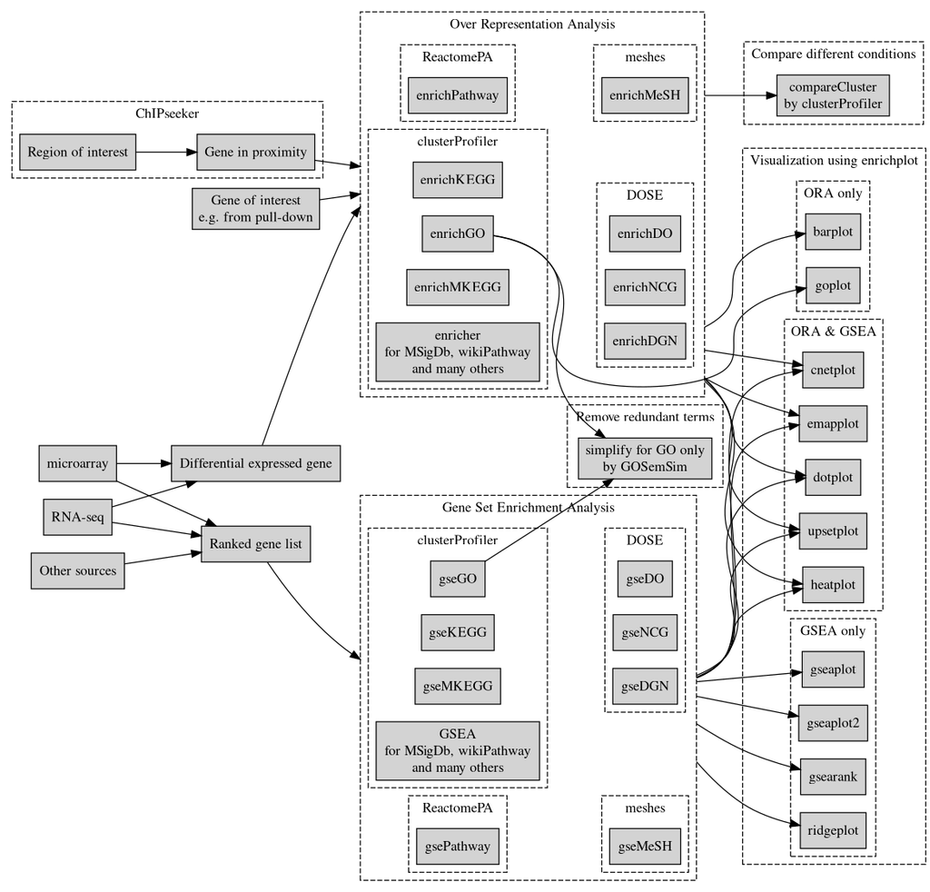

`clusterProfiler` abilities. [Source](https://yulab-smu.github.io/clusterProfiler-book/)

`clusterProfiler` needs a named vector where names are ENTREZIDs and values are some statistics, which can be used to sort this vector. In our case of RNA-seq data processed by `DESeq2`, we will use the Wald statistics, which are computed as `log2FoldChange / lfcSE` and which we have in column `stat` in `res_dex`. However, Wald statistics are missing in our shrunken results table (`res_dex_shrink`), but we can simply calculate them:

```r
res_dex_shrink$stat <- res_dex_shrink$log2FoldChange / res_dex_shrink$lfcSE
```

Next problem is that IDs of our genes are ENSEMBL IDs, but `clusterProfiler` needs ENTREZIDs. No worries, the `bitr()` function will help us.

```r
library(clusterProfiler)
```

```r
entrez_ids <- bitr(rownames(res_dex_shrink), fromType = "ENSEMBL", toType = "ENTREZID", OrgDb = "org.Hs.eg.db")
head(entrez_ids)
```

|  | ENSEMBL | ENTREZID |
| --- | --- | --- |
| 1 | ENSG00000000003 | 7105 |
| 2 | ENSG00000000419 | 8813 |
| 3 | ENSG00000000457 | 57147 |
| 4 | ENSG00000000460 | 55732 |
| 5 | ENSG00000000971 | 3075 |
| 6 | ENSG00000001036 | 2519 |

```r
any(duplicated(entrez_ids$ENSEMBL))
```

```
## [1] TRUE
```

```r
any(duplicated(entrez_ids$ENTREZID))
```

```
## [1] TRUE
```

There are always problems when you are converting gene IDs. Generally, you lost some genes, because they don’t have the other gene ID, or oppositely you obtain duplicates.

We will remove duplicated ENTREZIDs, add ENTREZIDs to `res_dex_shrink`, and create a named vector where names are ENTREZIDs and values are Wald statistics, sorted in decreasing order:

```r
entrez_ids <- entrez_ids[!duplicated(entrez_ids$ENTREZID), ]

res_dex_shrink <- res_dex_shrink %>%
  as.data.frame() %>%
  dplyr::mutate(ENSEMBL = rownames(.)) %>%
  dplyr::left_join(entrez_ids, by = "ENSEMBL") %>%
  dplyr::filter(!is.na(ENTREZID)) %>%
  magrittr::set_rownames(.$ENTREZID)

entrez_wald <- res_dex_shrink$stat
names(entrez_wald) <- res_dex_shrink$ENTREZID

# Sort by decreasing Wald statistic.
entrez_wald <- entrez_wald[order(entrez_wald, decreasing = TRUE)]
```

Similarly we prepare a named vector of LFCs:

```r
entrez_lfc <- res_dex_shrink$log2FoldChange
names(entrez_lfc) <- res_dex_shrink$ENTREZID
entrez_lfc <- entrez_lfc[order(entrez_lfc, decreasing = TRUE)]
```

So this is our list L:

```r
head(entrez_wald)
```

```
##      783     8404     1843    25939     4128     2878
## 24.61328 24.54713 24.04849 23.93725 23.41888 22.20143
```

Now we can run GSEA on KEGG pathways:

```r
gsea_kegg_results <- gseKEGG(
  geneList = entrez_wald,
  # KEGG organism ID
  organism = "hsa",
  # Key type is ENTREZ ID.
  keyType = "ncbi-geneid",
  # Correct p-values for FDR.
  pAdjustMethod = "fdr",
  # FDR adjusted p-value threshold.
  # We are OK with 10% of false positives among all pathways called significant.
  pvalueCutoff = 0.1,
  # Set a constant seed so you will get reproducible results using the same data.
  seed = 1,
  verbose = TRUE
)
```

```
## Reading KEGG annotation online:
##
## Reading KEGG annotation online:
##
## Reading KEGG annotation online:
```

```
## preparing geneSet collections...
```

```
## GSEA analysis...
```

```
## leading edge analysis...
```

```
## done...
```

```r
gsea_kegg_results
```

```
## #
## # Gene Set Enrichment Analysis
## #
## #...@organism     hsa
## #...@setType      KEGG
## #...@geneList     Named num [1:17158] 24.6 24.5 24 23.9 23.4 ...
##  - attr(*, "names")= chr [1:17158] "783" "8404" "1843" "25939" ...
## #...nPerm
## #...pvalues adjusted by 'fdr' with cutoff <0.1
## #...30 enriched terms found
## 'data.frame':    30 obs. of  11 variables:
##  $ ID             : chr  "hsa04140" "hsa04920" "hsa05135" "hsa04910" ...
##  $ Description    : chr  "Autophagy - animal" "Adipocytokine signaling pathway" "Yersinia infection" "Insulin signaling pathway" ...
##  $ setSize        : int  133 57 120 119 435 217 175 105 138 175 ...
##  $ enrichmentScore: num  0.59 0.677 0.565 0.566 -0.361 ...
##  $ NES            : num  1.81 1.84 1.7 1.71 -1.41 ...
##  $ pvalue         : num  5.39e-06 4.21e-05 1.44e-04 1.56e-04 1.66e-04 ...
##  $ p.adjust       : num  0.00179 0.00698 0.01105 0.01105 0.01105 ...
##  $ qvalues        : num  0.0015 0.00587 0.00929 0.00929 0.00929 ...
##  $ rank           : num  2312 1909 2603 2542 4097 ...
##  $ leading_edge   : chr  "tags=38%, list=13%, signal=33%" "tags=42%, list=11%, signal=38%" "tags=41%, list=15%, signal=35%" "tags=39%, list=15%, signal=34%" ...
##  $ core_enrichment: chr  "8660/5562/23604/8837/6009/5295/440738/5894/9706/3667/55062/22800/6237/81671/5293/5516/3480/10010/84557/23710/30"| __truncated__ "2180/8660/51422/5562/3952/3667/6774/1374/5781/2475/3717/7133/4792/51094/10645/1147/3551/5970/5465/79602/4793/6256/32/10000" "9475/6196/5295/10…
## #...Citation
##  T Wu, E Hu, S Xu, M Chen, P Guo, Z Dai, T Feng, L Zhou, W Tang, L Zhan, X Fu, S Liu, X Bo, and G Yu.
##  clusterProfiler 4.0: A universal enrichment tool for interpreting omics data.
##  The Innovation. 2021, 2(3):100141
```

We can retrieve the dataframe with enrichment results with

```r
as.data.frame(gsea_kegg_results)
```

|  | ID | Description | setSize | enrichmentScore | NES | pvalue | p.adjust | qvalues | rank | leading_edge | core_enrichment |
| --- | --- | --- | --- | --- | --- | --- | --- | --- | --- | --- | --- |
| hsa04140 | hsa04140 | Autophagy - animal | 133 | 0.5903829 | 1.808178 | 5.385242e-06 | 0.001787900 | 0.001502199 | 2312 | tags=38%, list=13%, signal=33% | 8660/5562/23604/8837/6009/5295/440738/5894/9706/3667/55062/2…… |
| hsa04920 | hsa04920 | Adipocytokine signaling pathway | 57 | 0.6765029 | 1.837204 | 4.207749e-05 | 0.006984864 | 0.005868703 | 1909 | tags=42%, list=11%, signal=38% | 2180/8660/51422/5562/3952/3667/6774/1374/5781/2475/3717/7133/4792/51094/10645/1147/3551/5970/5465/79602/4793/6256/32/10000 |
| hsa05135 | hsa05135 | Yersinia infection | 120 | 0.5649924 | 1.704418 | 1.437590e-04 | 0.011053721 | 0.009287369 | 2603 | tags=41%, list=15%, signal=35% | 9475/6196/5295/10092/64283/6093/5881/5293/10096/2185/71/5606…… |
| hsa04910 | hsa04910 | Insulin signaling pathway | 119 | 0.5655697 | 1.706919 | 1.559434e-04 | 0.011053721 | 0.009287369 | 2542 | tags=39%, list=15%, signal=34% | 3632/2308/8660/51422/5562/6009/5295/5894/5500/3667/5834/5293…… |
| hsa05168 | hsa05168 | Herpes simplex virus 1 infection | 435 | -0.3606836 | -1.408966 | 1.664717e-04 | 0.011053721 | 0.009287369 | 4097 | tags=43%, list=24%, signal=34% | 4615/115509/345462/388569/7561/7643/7728/30832/284323/581/84…… |
| hsa05131 | hsa05131 | Shigellosis | 217 | 0.4794956 | 1.548800 | 3.602759e-04 | 0.019935268 | 0.016749670 | 3237 | tags=43%, list=19%, signal=36% | 2308/9265/2309/10241/9475/5295/440738/23048/7414/10092/10627…… |
| hsa04810 | hsa04810 | Regulation of actin cytoskeleton | 175 | 0.4937223 | 1.560673 | 5.487267e-04 | 0.026025321 | 0.021866551 | 2072 | tags=38%, list=12%, signal=34% | 9475/5295/5894/8515/7414/10092/5500/4660/10627/85464/8516/22…… |
| hsa04152 | hsa04152 | AMPK signaling pathway | 105 | 0.5495642 | 1.627509 | 7.289814e-04 | 0.030252729 | 0.025418431 | 1909 | tags=30%, list=11%, signal=27% | 2308/8660/51422/5562/2309/6009/5295/3952/3667/55437/1374/5468/5293/5516/3480/23216/64764/890/5290/2475/81617/5862/5209/23417/29904/51094/10645/3643/51719/79602/32/10000 |
| hsa04150 | hsa04150 | mTOR signaling pathway | 138 | 0.5132436 | 1.576452 | 8.862019e-04 | 0.030887894 | 0.025952099 | 2613 | tags=36%, list=15%, signal=31% | 8325/5562/6196/6009/5295/5894/8323/9706/3667/55437/6502/8322…… |
| hsa05170 | hsa05170 | Human immunodeficiency virus 1 infection | 175 | 0.4868995 | 1.539106 | 9.303583e-04 | 0.030887894 | 0.025952099 | 2502 | tags=31%, list=15%, signal=27% | 25939/8907/5295/5894/59345/5881/5293/2185/836/5606/7465/3709…… |

[output cut: 20 more lines]

The results are sorted by adjusted p-values. Here is a description of some of its columns:

- `setSize`: number of genes in the pathway (gene set).
- `NES`: enrichment score normalized to gene set size.
- `leading_edge`:
  - *Tags* indicates the percentage of genes contributing to the enrichment score.
  - *List* indicates where in the list the enrichment score is attained.
  - *Signal* indicates enrichment signal strength.
- `core_enrichment`: genes in the leading-edge subset. Those are genes which contribute the most to the enrichment score and are located in the list before the running-sum statistic maximum.

Now we can visualize our results. First we will convert ENTREZIDs back to gene symbols:

```r
gsea_kegg_results <- setReadable(gsea_kegg_results, "org.Hs.eg.db", keyType = "ENTREZID")
```

`clusterProfiler` can also use `dplyr` verbs to [manipulate with enrichment results](https://yulab-smu.top/biomedical-knowledge-mining-book/clusterProfiler-dplyr.html). For example, we can filter gene sets having adjusted p-value under some threshold:

```r
gsea_kegg_results_filtered <- dplyr::filter(gsea_kegg_results, p.adjust < 0.05)
```

Now we will look at visualization of enrichment results. Most of the used functions return a `ggplot2` object, which can be easily modified, if needed.

## GSEA plot

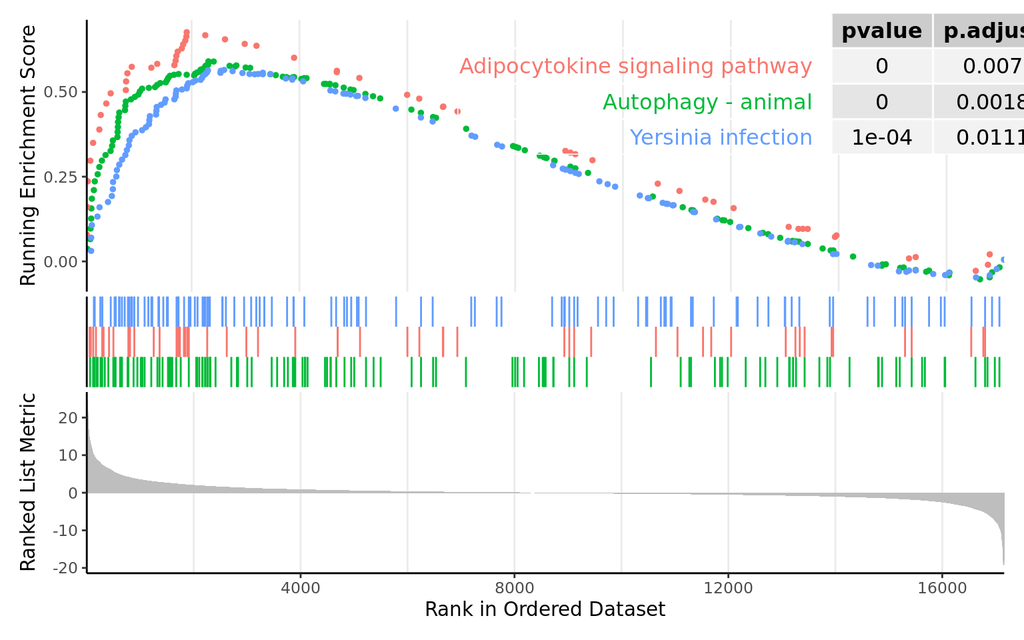

```r
library(enrichplot)
gseaplot2(gsea_kegg_results, geneSetID = 1:3, pvalue_table = TRUE, ES_geom = "dot")
```

The leading-edge subset is located before the running-sum statistic. Those are genes which contribute the most to the enrichment score and, in this case and for all the gene sets, they are located approximately on the left from the first grey vertical grid line.

You can check for the red pathway (“Adipocytokine signaling pathway”) that the number of genes in the leading-edge subset agrees between the GSEA plot (number of dots before the ES maximum) and the enrichment results:

```r
dplyr::filter(gsea_kegg_results, Description == "Adipocytokine signaling pathway") %>%
  .$core_enrichment %>%
  str_split(fixed("/")) %>%
  unlist() %>%
  length()
```

```
## [1] 24
```

## Dotplot

Dotplot shows how leading edge genes are distributed.

- `GeneRatio`: ratio of top scoring genes in a gene set.
- `Count`: number of top scoring genes in a gene set.

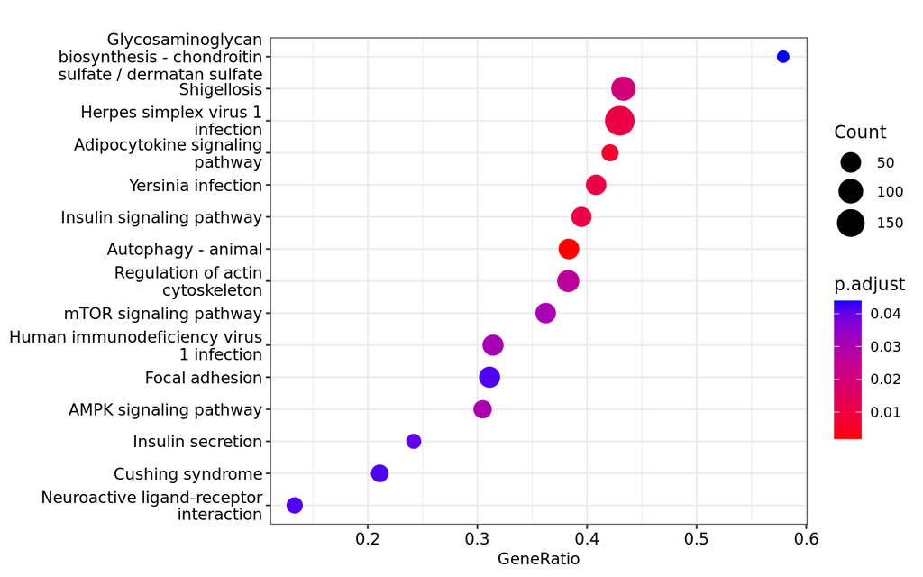

```r
dotplot(gsea_kegg_results, showCategory = 15, x = "GeneRatio", font.size = 10)
```

## Gene-Concept Network

The `cnetplot()` function depicts the linkages of genes and biological concepts (e.g. GO terms or KEGG pathways) as a network. Because it won’t fit inside the RMarkdown document, we will save it as a PNG file.

```r
p <- cnetplot(gsea_kegg_results, showCategory = 3, foldChange = entrez_lfc, colorEdge = TRUE)
p_file <- here("E07-RNA_seq/05_gene_set_analysis/gsea_cnetplot.png")
ggsave(p_file, p, device = "png", width = 10, height = 10)
```

gsea_cnetplot.png

## Gene-Concept Network in heatmap

We can also show the Gene-Concept Network in a heatmap.

```r
p <- heatplot(gsea_kegg_results, foldChange = entrez_lfc, showCategory = 3) +
  theme(axis.text.x = element_text(angle = 90, vjust = 2, size = 7))
p_file <- here("E07-RNA_seq/05_gene_set_analysis/gsea_heatmap.png")
ggsave(p_file, p, device = "png", width = 15, height = 5)
```

gsea_heatmap.png

## Enrichment map

Enrichment map organizes enriched terms into a network with edges connecting overlapping gene sets. In this way, mutually overlapping gene sets are tend to cluster together, making it easy to identify functional module.

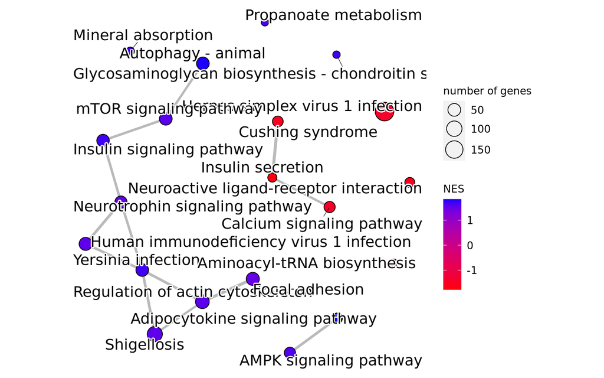

```r
gsea_kegg_results <- pairwise_termsim(gsea_kegg_results)
emapplot(gsea_kegg_results, color = "NES", showCategory = 20)
```

## PubMed Central plot

One of the problem of enrichment analysis is to find pathways for further investigation. The `pmcplot()` function plots the number/proportion of publications trend based on the query result from PubMed Central. All text that can be queried on PMC is valid as input of `pmcplot()`.

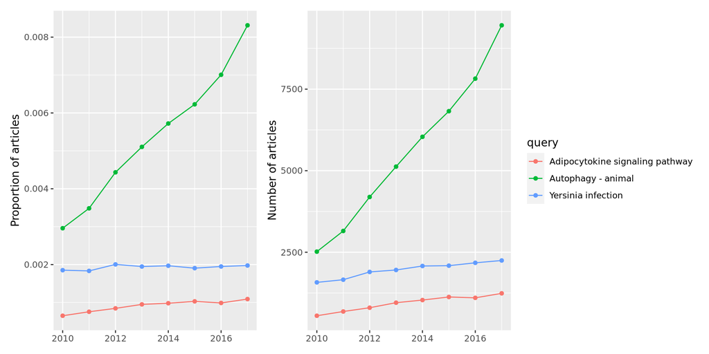

```r
terms <- gsea_kegg_results$Description[1:3]
p <- pmcplot(terms, 2010:2017)
p2 <- pmcplot(terms, 2010:2017, proportion = FALSE)
patchwork::wrap_plots(p, p2, ncol = 2, guides = "collect")
```

# GSEA on Reactome

For Reactome you can use [ReactomePA](https://bioconductor.org/packages/release/bioc/html/ReactomePA.html) package from the same author as `clusterProfiler`. The function for GSEA is `gsePathway()` and uses parameters similar to `gseKEGG()`.

# GSEA on MSigDB

For MSigDB, you have to first get gene sets of interest. This is nicely described [here](https://yulab-smu.github.io/clusterProfiler-book/chapter3.html#msigdb-analysis). Alternatively, you can download GMT files used to store gene sets which are available on the [MSigDB webpage](http://www.gsea-msigdb.org/gsea/downloads.jsp), and parse them to dataframe with `read.gmt()` function.

# Signaling pathway impact analysis (SPIA)

[SPIA](https://bioconductor.org/packages/release/bioc/html/SPIA.html) tries to estimate the effect on a pathway, which must be curated and influence of a change in gene expression on the pathway output is known. It uses [KEGG](https://www.genome.jp/kegg/) curated signaling pathways.

`SPIA` calculates two statistics:

- **Over-representation** (ORA) of DEGs in the pathway.
- **Perturbation** (PERT): the influence of observed expression changes on pathway output.

Significant pathways will have both ORA and PERT high.

To use `SPIA`, you need to preprocess KGML files defining the KEGG pathways. KGML is a special XML format describing members of a pathway and their connections and influence. You have two options how to download KGML files:

- Through your web browser on the KEGG web ([example](https://www.genome.jp/kegg-bin/show_pathway?map=hsa04110&show_description=show)).
- Using the KEGG REST API where KGML files are available at `http://rest.kegg.jp/get/<pathway_id>/kgml` (and for pathway images you can use `http://rest.kegg.jp/get/<pathway_id>/png`). This way is better for a programmatic access, and so we will use it.

```r
KEGG_DATA_DIR <- here("E07-RNA_seq/05_gene_set_analysis/kegg_data")
dir.create(KEGG_DATA_DIR)
kegg_ids <- gsea_kegg_results@result$ID[1:5]
purrr::map(kegg_ids, ~ download.file(glue("http://rest.kegg.jp/get/{.}/kgml"), glue("{KEGG_DATA_DIR}/{.}.xml")))
```

Then KGML files need to be prepared for `SPIA`, simply by an included function which will save processed data in Rds format.

```r
library(SPIA)

makeSPIAdata(
  kgml.path = KEGG_DATA_DIR,
  organism = "hsa",
  out.path = KEGG_DATA_DIR
)
```

```
## [1] TRUE
```

As for `clusterProfiler`, `SPIA` needs a named vector as input, but instead of t-statistics, it needs LFCs od DEGs. Let’s prepare it:

```r
deg_entrezids <- res_dex_shrink[deg_filter, "ENTREZID"]
# Vector of LFCs of DEGs. Names are ENTREZIDs.
entrez_lfc_deg <- entrez_lfc[deg_entrezids]
entrez_lfc_deg <- entrez_lfc_deg[order(entrez_lfc_deg, decreasing = TRUE)]
head(entrez_lfc_deg)
```

```
##     1301    28984     5166    10272    23604     8735
## 2.395663 2.225642 1.952421 1.794119 1.633506 1.590197
```

Now let’s run `SPIA`:

```r
spia_results <- spia(
  de = entrez_lfc_deg,
  all = res_dex_shrink$ENTREZID,
  organism = "hsa",
  data.dir = paste0(KEGG_DATA_DIR, "/")
)
```

[output not shown]

```r
spia_results
```

| Name | ID | pSize | NDE | pNDE | tA | pPERT | pG | pGFdr | pGFWER | Status | KEGGLINK |
| --- | --- | --- | --- | --- | --- | --- | --- | --- | --- | --- | --- |
| Yersinia infection | 05135 | 120 | 11 | 0.01079798 | 2.1728515 | 0.460 | 0.03131701 | 0.1479084 | 0.2192191 | Activated | http://www.genome.jp/dbget-bin/show_pathway?hsa05135+1399+60+7454+4210+29108+27330+8935+5601+5606+5291+920 |
| Adipocytokine signaling pathway | 04920 | 57 | 4 | 0.20818708 | 1.4891555 | 0.055 | 0.06263011 | 0.1479084 | 0.4384108 | Activated | http://www.genome.jp/dbget-bin/show_pathway?hsa04920+2182+79602+7133+5601 |
| Autophagy - animal | 04140 | 133 | 9 | 0.09931985 | 3.3094004 | 0.117 | 0.06338930 | 0.1479084 | 0.4437251 | Activated | http://www.genome.jp/dbget-bin/show_pathway?hsa04140+5291+58528+5601+572+23604+55054+8837+11345+81671 |
| Regulation of actin cytoskeleton | 04810 | 175 | 11 | 0.10928056 | -4.0325332 | 0.155 | 0.08601647 | 0.1505288 | 0.6021153 | Inhibited | http://www.genome.jp/dbget-bin/show_pathway?hsa04810+5217+10787+7414+87+5063+5291+1399+3674+3675+2263+60 |
| Shigellosis | 05131 | 216 | 13 | 0.11198519 | 1.1093464 | 0.579 | 0.24222981 | 0.3391217 | 1.0000000 | Activated | http://www.genome.jp/dbget-bin/show_pathway?hsa05131+23291+5601+29108+58528+55054+11345+1399+60+7414+87+5291+823+5217 |
| Insulin signaling pathway | 04910 | 119 | 7 | 0.22090905 | 1.2727122 | 0.483 | 0.34546415 | 0.4030415 | 1.0000000 | Activated | http://www.genome.jp/dbget-bin/show_pathway?hsa04910+5601+8569+89801+5577+572+5291+1399 |
| Herpes simplex virus 1 infection | 05168 | 435 | 11 | 0.97282536 | -0.6119116 | 0.329 | 0.68468681 | 0.6846868 | 1.0000000 | Inhibited | http://www.genome.jp/dbget-bin/show_pathway?hsa05168+5452+6672+5610+355+841+5291+572+7748+7752+7771+8891 |

We got a dataframe with several columns:

- **pSize**: number of genes in the pathway.
- **NDE**: the number of DE genes per pathway.
- **tA**: the observed total perturbation accumulation in the pathway.
- **pNDE**: the probability to observe at least NDE genes on the pathway using a hypergeometric model.
- **pPERT**: the probability to observe a total accumulation more extreme than tA only by chance.
- **pG**: the p-value obtained by combining pNDE and pPERT.
- **pGFdr** and **pGFWER**: the False Discovery Rate and respectively Bonferroni adjusted global p-values.
- **Status**: gives the direction in which the pathway is perturbed (activated or inhibited).
- **KEGGLINK**: gives a web link to the KEGG website that displays the pathway image with the differentially expressed genes highlighted in red.

Now we will look at the two-evidence plot. Note that we are using an extremely high p-value threshold, but only for the purpose of this exercise. Otherwise this function will unexpectedly throw an error, because no significant pathways will meet the threshold.

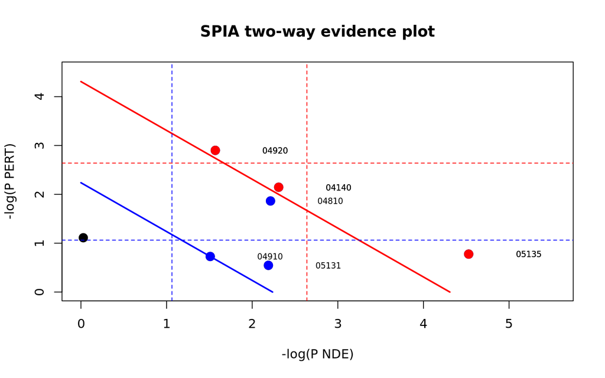

```r
plotP(spia_results, threshold = 0.5)
```

- The horizontal axis represents the p-value (minus log of) corresponding to the probability of obtaining at least the observed number of genes (NDE) on the given pathway just by chance.
- The vertical axis represents the p-value (minus log of) corresponding to the probability of obtaining the observed total accumulation (tA) or more extreme on the given pathway just by chance.
- The pathways at the right of the red oblique line are significant after Bonferroni correction of the global p-values (pG), obtained by combining the pPERT and pNDE using Fisher’s method.
- The pathways at the right of the blue oblique line are significant after a FDR correction of the global p-values (pG).

# Viewing data in KEGG

[Pathview](https://bioconductor.org/packages/release/bioc/html/pathview.html) is a great package for generation of colorized KEGG pathways. It can also download KGML files and store them for later.

```r
library(pathview)
pathway_id <- gsea_kegg_results$ID[1]
pathview_out_file <- glue("{pathway_id}.pathview.png")

pathview(
  # A named vector of LFCs to color pathway by.
  gene.data = entrez_lfc_deg,
  # We use the first most significant pathway from GSEA.
  pathway.id = pathway_id,
  species = "hsa",
  # Coloring range <min LFC; max LFC>
  # limit = list(gene = max(abs(entrez_lfc_deg)), cpd = 1),
  kegg.dir = paste0(KEGG_DATA_DIR, "/")
)
```

```
## Info: Working in directory /data/persistent/jirinovo/AGE/Exercises
```

```
## Info: Writing image file hsa04140.pathview.png
```

```r
file.rename(here(pathview_out_file), here("E07-RNA_seq/05_gene_set_analysis", pathview_out_file))
```

hsa04140.pathview.png

> For some reason, `pathview` doesn’t allow to specify a path to output directory or file, and saves the result to current working directory. So when you call the `pathview()` function from the R console, the result will be saved to project’s root directory, while the call from within a code chunk in a Rmd file will save the result to the Rmd file’s location, which is the default working directory for `render()` (respectively for `knitr` package) 😭. This is also the case when RStudio is not set to evaluate Rmd code chunks in project’s root directory, see E02 - Intro / Reproducible R. However, we can override this behaviour by setting `knit_root_dir = here()` inside `render()`, see the HTML rendering section.

# Online tools

These are some online tools for GSEA (ORA):

- [g:Profiler](https://biit.cs.ut.ee/gprofiler/gost)
- [Enrichr](http://amp.pharm.mssm.edu/Enrichr/)
- [WEB-based GEne SeT AnaLysis Toolkit](http://www.webgestalt.org/)
- [DAVID](https://david.ncifcrf.gov/)
- [Reactome](https://www.reactome.org/)

# Cleanup

```r
save(list = ls(all.names = TRUE), file = here("E07-RNA_seq/05_gene_set_analysis/05_gene_set_analysis.RData"), envir = environment())

warnings()
traceback()
```

```
## No traceback available
```

# HTML rendering

This chunk is not evaluated (`eval = FALSE`). Otherwise you will probably end up in recursive hell 🤯

```r
library(conflicted)
library(knitr)
library(here)

if (!require(rmdformats)) {
  BiocManager::install("rmdformats")
}

# You can set global chunk options. Options set in individual chunks will override this.
opts_chunk$set(warning = FALSE, message = FALSE, eval = TRUE)
rmarkdown::render(
  here("E07-RNA_seq/05_gene_set_analysis/05_gene_set_analysis.Rmd"),
  output_file = here("E07-RNA_seq/05_gene_set_analysis/05_gene_set_analysis.html"),
  envir = new.env(),
  knit_root_dir = here()
)
```